# Homework 10

Solutions for Questions 1 and 2 will be available after Monday, November 2, 2026. No solution will be provided for Question 3.

Use the RLT package for Questions 1 and 2: `RLT` in R or `rlt` in Python. The node-size parameter is `nmin` in R and `min_samples_leaf` in Python; both stop splitting a node when it contains at most that many observations. The candidate-predictor parameter is `mtry` in both languages. Use ordinary random forests, with reinforcement turned off.

## Question 1: Bias-variance trade-off simulation

Two important tuning parameters of random forests are node size and `mtry`. We have performed some preliminary analysis in class. The goal of this question is to perform a larger simulation study for these two tuning parameters.

Consider a regression model with five jointly normally distributed predictors. Each predictor has mean 0 and variance 1, and the correlation between any two different predictors is 0.3. The response is

$$Y=X_1+X_3+X_5+\varepsilon,
\qquad \varepsilon\sim N(0,1),$$

where the noise is independent of the predictors. Thus the true regression function is $f(\mathbf{x})=x_1+x_3+x_5$.

1. Set up a simulation study with 100 repetitions. Generate 200 test predictor vectors once and keep them fixed. In each repetition, generate 200 new training observations and use the same training data for all tuning settings. Fit 500-tree forests, drawing 200 observations with replacement for each tree. Make the following two comparisons:
   - Fix `mtry` at 3 and vary node size over $1,5,10,20,30$.
   - Fix node size at 10 and vary `mtry` over $1,2,3,4,5$.

   Leave all other fitting parameters at their defaults. Record the predictions at each test point across repetitions. For each setting, estimate the squared bias and variance at each test point, then average them over the 200 test points. Compare predictions with $f(\mathbf{x})$ when estimating bias. Produce two figures, one for each tuning parameter, showing the averaged squared bias and variance. Set a random seed and report it.
2. Discuss your results in terms of the bias-variance trade-off:
   - How does a large node size, such as 30, affect the fit in this example?
   - What are the benefits and drawbacks of using a large `mtry` value?
   - If each tree instead sampled 100 observations with replacement, would you expect the preferred node size to shift toward smaller or larger values? Explain your reasoning. You may use an additional simulation to help, but a particular pattern is not guaranteed.

**Answer 1.** I used R with `RLT` 6.1.1 and seed **432**. `set.seed(432)` generates the fixed test points and all training data, and each forest gets its own RLT seed, $432000+100r+s$ for repetition $r$ and setting $s$, so every fit is reproducible. The predictors are drawn as $\mathbf X=\mathbf Z\mathbf R$, where $\mathbf Z$ is standard normal and $\mathbf R$ is the Cholesky factor of the equicorrelation matrix ($\rho=0.3$). Each forest uses 500 trees, `resample.replace = TRUE`, and `resample.prob = 1` (200 of the 200 training rows), with reinforcement off and every other setting at its default. For each setting and test point $\mathbf x_j$, with $\hat f_r(\mathbf x_j)$ the prediction in repetition $r$,

$$\widehat{\text{Bias}}^2_j=\Big(\tfrac{1}{100}\textstyle\sum_r \hat f_r(\mathbf x_j)-f(\mathbf x_j)\Big)^2,
\qquad
\widehat{\text{Var}}_j=\tfrac{1}{100}\textstyle\sum_r\big(\hat f_r(\mathbf x_j)-\bar f(\mathbf x_j)\big)^2,$$

and I average both over the 200 test points.

**Show the workflow**

```r
library(RLT)
set.seed(432)
p <- 5
Sigma <- matrix(0.3, p, p); diag(Sigma) <- 1
R <- chol(Sigma)
gen_x <- function(n) matrix(rnorm(n * p), n, p) %*% R
f_true <- function(X) X[, 1] + X[, 3] + X[, 5]

X_test <- gen_x(200)                 # fixed for the whole study
f_test <- f_true(X_test)
nrep <- 100
settings <- rbind(data.frame(study = "nodesize", mtry = 3, nmin = c(1, 5, 10, 20, 30)),
                  data.frame(study = "mtry", mtry = 1:5, nmin = 10))

run_study <- function(settings, prob, nrep) {
  pred <- array(NA_real_, c(nrep, nrow(settings), nrow(X_test)))
  for (r in 1:nrep) {
    X <- gen_x(200)                    # same training data for every setting
    y <- f_true(X) + rnorm(200)
    for (s in seq_len(nrow(settings))) {
      fit <- RLT(X, y, model = "regression", ntrees = 500,
                 mtry = settings$mtry[s], nmin = settings$nmin[s],
                 resample.replace = TRUE, resample.prob = prob,
                 reinforcement = FALSE, ncores = 2, seed = 432000 + 100 * r + s)
      pred[r, s, ] <- predict(fit, X_test)$Prediction[, 1]
    }
  }
  bias2 <- apply(pred, 2, function(m) mean((colMeans(m) - f_test)^2))
  variance <- apply(pred, 2, function(m) mean(apply(m, 2, function(v) mean((v - mean(v))^2))))
  cbind(settings, bias2 = bias2, variance = variance, total = bias2 + variance)
}

res <- run_study(settings, prob = 1, nrep = nrep)
print(res, digits = 3, row.names = FALSE)
```

```
    study mtry nmin bias2 variance total
 nodesize    3    1 0.109    0.195 0.304
 nodesize    3    5 0.111    0.190 0.301
 nodesize    3   10 0.119    0.177 0.296
 nodesize    3   20 0.157    0.161 0.318
 nodesize    3   30 0.213    0.156 0.369
     mtry    1   10 0.398    0.109 0.507
     mtry    2   10 0.170    0.142 0.312
     mtry    3   10 0.120    0.176 0.296
     mtry    4   10 0.106    0.203 0.309
     mtry    5   10 0.101    0.223 0.324
```

**Show the workflow**

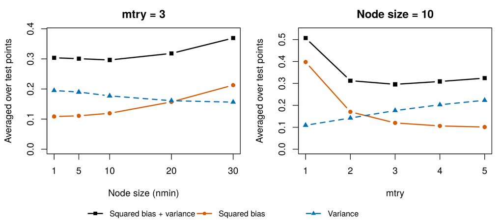

Squared bias, variance, and their sum, averaged over the 200 fixed test points (100 repetitions, 200 observations per tree). Left: mtry = 3, varying node size. Right: node size 10, varying mtry.

```r
plot_bv <- function(d, x, xlab, main) {
  yl <- c(0, max(d$total) * 1.05)
  plot(d[[x]], d$total, type = "b", pch = 15, lwd = 2, col = "black", ylim = yl,
       xlab = xlab, ylab = "Averaged over test points", main = main, xaxt = "n")
  axis(1, at = d[[x]])
  lines(d[[x]], d$bias2, type = "b", pch = 16, lwd = 2, col = "#D55E00")
  lines(d[[x]], d$variance, type = "b", pch = 17, lwd = 2, col = "#0072B2", lty = 2)
}
op <- par(mfrow = c(1, 2), mar = c(4.2, 4.2, 2.5, 1), oma = c(2, 0, 0, 0))
plot_bv(subset(res, study == "nodesize"), "nmin", "Node size (nmin)", "mtry = 3")
plot_bv(subset(res, study == "mtry"), "mtry", "mtry", "Node size = 10")
par(fig = c(0, 1, 0, 1), oma = c(0, 0, 0, 0), mar = c(0, 0, 0, 0), new = TRUE)
plot(0, 0, type = "n", bty = "n", xaxt = "n", yaxt = "n", xlab = "", ylab = "")
legend("bottom", c("Squared bias + variance", "Squared bias", "Variance"), horiz = TRUE,
       col = c("black", "#D55E00", "#0072B2"), pch = c(15, 16, 17), lty = c(1, 1, 2),
       lwd = 2, bty = "n", cex = 0.85)
```

**Show the workflow**

```r
par(op)
```

| Setting | Squared bias | Variance | Sum |
| --- | --- | --- | --- |
| mtry 3, node size 1 | 0.109 | 0.195 | 0.304 |
| mtry 3, node size 5 | 0.111 | 0.190 | 0.301 |
| mtry 3, node size 10 | 0.119 | 0.177 | **0.296** |
| mtry 3, node size 20 | 0.157 | 0.161 | 0.318 |
| mtry 3, node size 30 | 0.213 | 0.156 | 0.369 |
| node size 10, mtry 1 | 0.398 | 0.109 | 0.507 |
| node size 10, mtry 2 | 0.170 | 0.142 | 0.312 |
| node size 10, mtry 3 | 0.120 | 0.176 | **0.296** |
| node size 10, mtry 4 | 0.106 | 0.203 | 0.309 |
| node size 10, mtry 5 | 0.101 | 0.223 | 0.324 |

(The two rows with mtry 3 and node size 10 agree to rounding. They are separate fits on the same data with different forest seeds.)

**b.**

**Large node size.** A node size of 30 smooths each tree heavily. With only 200 observations per tree, a node can’t split once it holds 30 or fewer, so each tree has relatively few terminal nodes and predicts a coarse local average. That roughly doubles the squared bias, from 0.11 at node size 1 to 0.21 at 30, while variance falls only modestly, from 0.195 to 0.156. The forest already averages 500 trees, so it has less variance to remove, and the extra bias dominates. The total error is lowest at node size 10 (0.296), and the curve is flat between 1 and 10. In this example a node size of 30 underfits the linear signal $x_1+x_3+x_5$, especially in the tails, where wide terminal nodes pull predictions toward the middle.

**Large mtry.** Only $X_1$, $X_3$, and $X_5$ matter. With a large `mtry`, each split is more likely to find one of them, so trees are more accurate and squared bias drops, from 0.398 at `mtry = 1` to 0.101 at `mtry = 5`. The drawback is that trees become more alike: with `mtry = 5`, every tree considers every predictor at every split, so they differ only through their bootstrap samples. Averaging correlated trees removes less variance, which rises from 0.109 to 0.223. `mtry = 1` forces many splits on the two noise predictors $X_2$ and $X_4$, so its bias is very large, and `mtry = 5` has the largest variance. The balance is best at `mtry = 3` (0.296), with `mtry` 2 and 4 close behind.

**Sampling 100 observations per tree.** I expect the preferred node size to shift **smaller**. With half as many observations in each tree, a given node size covers a larger share of the sample, so the same `nmin` produces fewer, wider terminal nodes and more bias. Subsampling also makes the trees less correlated, which lowers the variance of their average. So the forest can afford deeper, lower-bias trees. The extra simulation below (same seed scheme, `mtry = 3`, `resample.prob = 0.5`) agrees. The total is lowest at node size 1 (0.293) and nearly the same at 5 (0.294), versus 10 when each tree used 200 observations. Variance is lower at every node size than with 200 observations, while squared bias rises quickly with node size and reaches 0.436 at 30.

**Show the workflow**

```r
res100 <- run_study(settings[settings$study == "nodesize", ], prob = 0.5, nrep = nrep)
print(res100, digits = 3, row.names = FALSE)
```

```
    study mtry nmin bias2 variance total
 nodesize    3    1 0.163    0.130 0.293
 nodesize    3    5 0.168    0.126 0.294
 nodesize    3   10 0.193    0.118 0.311
 nodesize    3   20 0.290    0.114 0.404
 nodesize    3   30 0.436    0.117 0.552
```

## Question 2: Tuning random forests for MNIST

Use `mnist-first2000.csv.gz` from the combined ZIP. It contains 2,000 MNIST observations, with the digit label `Digit` and 784 pixel values.

- From the first 1,000 observations, keep digits 1, 6, and 7 as the training data. From the remaining 1,000 observations, keep the same digits as the test data.
- Fit PCA to the training pixels, centering but not scaling them. Use the first 20 principal components as predictors, and project the test observations using the same training means and loadings.

Complete the following tasks using RLT classification forests with 1,000 trees. For each tree, draw a bootstrap sample of the same size as the training set.

1. Fit a random forest with the default `mtry` and node-size settings. Report the out-of-bag (OOB) misclassification rate.
2. Construct a grid of `mtry` and node-size values to tune the model. Select the setting using OOB misclassification rate. Report the OOB error for each setting and the selected values. Calculate and present the selected forest’s OOB permutation variable importance for the 20 principal components. Comment on your results.
3. Apply the selected model to the test data and report the misclassification rate and confusion matrix. Use the test labels only for this final assessment.

**Answer 2.** The training set is the digits 1, 6, and 7 among the first 1,000 rows (327 images: 116, 94, and 117). The test set is the same digits among rows 1,001 to 2,000 (317 images: 104, 106, and 107). PCA is fit on the training pixels with `prcomp(center = TRUE, scale. = FALSE)`, and the first 20 components explain 77.1% of the pixel variance. Test images are centered with the training means and projected onto the training loadings. Every forest uses 1,000 trees, bootstrap samples of size 327 (`resample.replace = TRUE`, `resample.prob = 1`), RLT seed 432, and no reinforcement.

**Show the workflow**

```r
mnist <- read.csv("data/mnist-first2000.csv.gz")
keep <- c(1, 6, 7)
train <- mnist[1:1000, ];    train <- train[train$Digit %in% keep, ]
test <- mnist[1001:2000, ];  test <- test[test$Digit %in% keep, ]
pixels <- setdiff(names(mnist), "Digit")

pca <- prcomp(train[, pixels], center = TRUE, scale. = FALSE)
Z_train <- pca$x[, 1:20]
Z_test <- scale(as.matrix(test[, pixels]), center = pca$center, scale = FALSE) %*%
  pca$rotation[, 1:20]
y_train <- factor(train$Digit)
y_test <- factor(test$Digit, levels = levels(y_train))   # used only in part c

cat("training:", nrow(train), "(", table(train$Digit), ")  test:", nrow(test),
    "(", table(test$Digit), ")\n")
```

```
training: 327 ( 116 94 117 )  test: 317 ( 104 106 107 )
```

**Show the workflow**

```r
cat("variance explained by 20 PCs:", round(sum(pca$sdev[1:20]^2) / sum(pca$sdev^2), 4), "\n")
```

```
variance explained by 20 PCs: 0.7713
```

**a.**

**Show the workflow**

```r
fit_default <- RLT(Z_train, y_train, model = "classification", ntrees = 1000,
                   resample.replace = TRUE, resample.prob = 1,
                   reinforcement = FALSE, ncores = 2, seed = 432)
cat("default mtry =", max(1, as.integer(ncol(Z_train) / 2)), ", nmin = 5; OOB error =",
    round(fit_default$Error, 4), "\n")
```

```
default mtry = 10 , nmin = 5; OOB error = 0.0428
```

With RLT’s defaults (`mtry` $=\lfloor 20/2\rfloor=10$, `nmin` $=5$), the OOB misclassification rate is **0.0428** (14 of 327).

**b.** The grid is `mtry` $\in\{1,2,4,7,10,15,20\}$ × node size $\in\{1,5,10,20\}$, 28 settings, all with the same trees, bootstrap scheme, and seed.

**Show the workflow**

```r
grid <- expand.grid(mtry = c(1, 2, 4, 7, 10, 15, 20), nmin = c(1, 5, 10, 20))
grid$oob <- NA_real_
for (i in seq_len(nrow(grid))) {
  fit <- RLT(Z_train, y_train, model = "classification", ntrees = 1000,
             mtry = grid$mtry[i], nmin = grid$nmin[i],
             resample.replace = TRUE, resample.prob = 1,
             reinforcement = FALSE, ncores = 2, seed = 432)
  grid$oob[i] <- fit$Error
}
round(xtabs(oob ~ mtry + nmin, grid), 4)
```

```
    nmin
mtry      1      5     10     20
  1  0.0153 0.0214 0.0245 0.0275
  2  0.0367 0.0336 0.0367 0.0367
  4  0.0367 0.0398 0.0398 0.0367
  7  0.0398 0.0367 0.0367 0.0428
  10 0.0459 0.0428 0.0428 0.0459
  15 0.0489 0.0459 0.0489 0.0489
  20 0.0489 0.0489 0.0489 0.0520
```

**Show the workflow**

```r
sel <- grid[which.min(grid$oob), ]
sel
```

```
  mtry nmin        oob
1    1    1 0.01529052
```

| `mtry` \ node size | 1 | 5 | 10 | 20 |
| --- | --- | --- | --- | --- |
| 1 | **0.0153** | 0.0214 | 0.0245 | 0.0275 |
| 2 | 0.0367 | 0.0336 | 0.0367 | 0.0367 |
| 4 | 0.0367 | 0.0398 | 0.0398 | 0.0367 |
| 7 | 0.0398 | 0.0367 | 0.0367 | 0.0428 |
| 10 | 0.0459 | 0.0428 | 0.0428 | 0.0459 |
| 15 | 0.0489 | 0.0459 | 0.0489 | 0.0489 |
| 20 | 0.0489 | 0.0489 | 0.0489 | 0.0520 |

The lowest OOB error is **`mtry = 1`, node size 1**, at 0.0153 (5 of 327), so this is the selected setting.

**Show the workflow**

```r
fit_best <- RLT(Z_train, y_train, model = "classification", ntrees = 1000,
                mtry = sel$mtry, nmin = sel$nmin, resample.replace = TRUE,
                resample.prob = 1, importance = "permute",
                reinforcement = FALSE, ncores = 2, seed = 432)
vi <- as.data.frame(importance(fit_best))
vi <- vi[order(-vi$VI), c("Variable", "VI")]
print(vi, row.names = FALSE, digits = 3)
```

```
 Variable     VI
      PC2 0.1295
      PC1 0.0948
      PC3 0.0340
      PC5 0.0325
      PC6 0.0294
      PC7 0.0245
     PC11 0.0234
     PC18 0.0213
     PC10 0.0201
     PC12 0.0186
     PC16 0.0182
      PC4 0.0179
     PC14 0.0177
     PC13 0.0151
     PC20 0.0150
     PC19 0.0141
      PC8 0.0139
      PC9 0.0135
     PC17 0.0134
     PC15 0.0115
```

**Show the workflow**

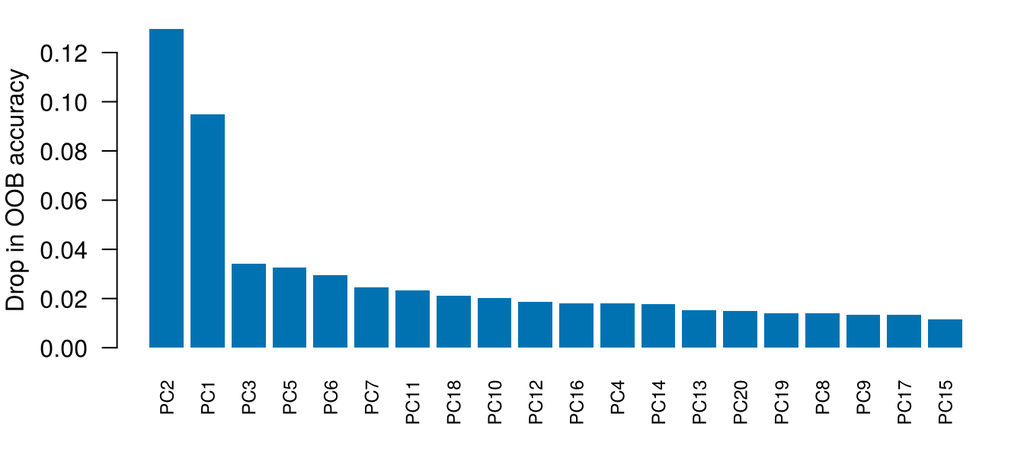

OOB permutation importance of the 20 principal components in the selected forest (mtry = 1, node size 1).

```r
op <- par(mar = c(4, 4, 1, 1))
barplot(vi$VI, names.arg = vi$Variable, las = 2, col = "#0072B2", border = NA,
        ylab = "Drop in OOB accuracy", cex.names = 0.75)
```

**Show the workflow**

```r
par(op)
```

**c.**

**Show the workflow**

```r
pred_test <- predict(fit_best, Z_test)$Prediction
cat("test misclassification rate:", round(mean(pred_test != y_test), 4),
    "(", sum(pred_test != y_test), "of", length(y_test), ")\n")
```

```
test misclassification rate: 0.0158 ( 5 of 317 )
```

**Show the workflow**

```r
table(Observed = y_test, Predicted = pred_test)
```

```
        Predicted
Observed   1   6   7
       1 102   0   2
       6   0 106   0
       7   0   3 104
```

The selected forest misclassifies 5 of 317 test images, a **test misclassification rate of 0.0158**, close to its OOB estimate of 0.0153.

| Observed \ Predicted | 1 | 6 | 7 |
| --- | --- | --- | --- |
| **1** | 102 | 0 | 2 |
| **6** | 0 | 106 | 0 |
| **7** | 0 | 3 | 104 |

Every 6 is classified correctly. The errors are two 1s predicted as 7, which share a vertical stroke, and three 7s predicted as 6.

## Question 3: Planning a random-forest analysis skill

In earlier homework, some students wrote long skill files with detailed instructions, while others wrote short skills emphasizing their specific requirements or references. These approaches may perform differently depending on the AI and the task. A capable AI may already know standard ways to perform an analysis, so some instructions may be redundant, add little value, or sometimes make the analysis worse. It may be more useful to specify your personal choices for the analysis. An AI with more limited knowledge may benefit from detailed instructions that remind it of the steps to perform.

1. Write one paragraph describing how you would write a skill that directs an AI to perform a random-forest analysis and produce a report for a future dataset. Discuss how you would balance standard analysis instructions with your personal preferences, considering the AI’s capabilities.
2. Provide **10 instructions** you would consider including in the skill, **ordered from the most basic instructions to the more personal preferences**. Your list may cover computation, tuning, tables, figures, interpretation, presentation, or other aspects of a random-forest report.

You only need to discuss how the skill should be written. You are not required to write a complete skill file or test it.

**Answer 3.**

**a.** I would write the skill around what a capable model is most likely to get wrong or to decide differently from me, not around textbook steps it already knows. Current models know how to fit a random forest, read OOB error, and compute permutation importance, so spelling out those steps mostly adds length. It can also cause harm when a generic instruction overrides a better default for the data at hand. The parts worth writing down are my choices: how tuning is evaluated and settled when candidates are within noise, which settings must be reported, what the figure and table look like, and how much space the report gets. I would keep a short layer of basic guardrails, such as never touching the test set during tuning and reporting the seed. These are cheap to state, and even a strong model occasionally slips on them. Two peer reviews also taught me that ambiguity is the main failure mode. Rules like “within one SE” or “the class of interest” need an exact definition, or two agents will make different choices. If I expected a weaker model, I would add a short checklist of the standard steps near the top, but keep the personal preferences unchanged at the end, so the skill can be trimmed for stronger models without losing what makes it mine. I would then test it on a dataset it was not written for, and cut any line that does not change the output.

**b.** Ten instructions, from most basic to most personal:

1. Report n, p, the response type, class counts or the response range, and missing values. Stop and ask if predictors have missing values, rather than imputing outside the resampling.
2. Set and report one seed, and the package and version used. Use the same seed for the forest, any split, and any folds.
3. If a test set is given or created, use it exactly once, after the final setting is chosen. Tune with OOB error or CV inside the training data only.
4. Use enough trees for OOB error to stabilize (for example, 500 to 1,000), and show this with OOB error against the number of trees for the final forest.
5. Tune `mtry` and node size together on a small grid (about 3 to 5 values each, including the defaults), with the same trees, sampling scheme, and seed for every setting.
6. Choose the final setting with a one-SE rule. Compute the threshold as the minimum OOB or CV error plus the SE of that minimum-error setting, then prefer the default `mtry` and the larger node size among settings below it. Report whether this changed the choice.
7. Report permutation importance from the final forest, with the importance of a randomly permuted noise predictor as a reference line, so readers can see which predictors are clearly above noise.
8. Use one figure, with a tuning heat map of OOB error over `mtry` and node size, the selected cell marked, and importance as a second small panel. Use one table of the best settings, and a confusion matrix or test RMSE for the final model.
9. Interpret importance as predictive contribution only, not as an effect size or causal claim. When predictors are correlated or are derived components such as PCs, say so explicitly.
10. Keep the report to one printed page at 11-point font: setup in two sentences, then the figure, table, final result, and three sentences each of findings and limitations. Write plainly, with no filler, round errors to three decimals, and make every number traceable to printed output.